# 第1章 回帰モデルとスパース推定

Osamu, MORIMOTO

2023-10-12

## 2. サンプルサイズよりも説明変数の数の方が多いケース。

### 準備

最初にこれから使用するパッケージを一通り呼び出しておく。

```r
if (!require("pacman")) {install.packages("pacman")} # パッケージ管理
pacman::p_load(
  conflicted,   # 関数名の衝突防止
  tidyverse,    # モダンなデータ操作
  glmnetUtils,  # 正則化回帰。テキストと違うが、こちらの方がformulaで書けるのでこちらを使う
  rsample,      # 学習データ、検証データ分割
  plotmo,       # glmnetの結果のλの変化と回帰係数の関係図
  patchwork,    # ggplot2の図をレイアウトする
  MLmetrics,    # 評価指標
  withr,        # 乱数種固定
  summarytools, # データの概要把握（EDA）
  GGally,       # データの概要把握（EDA）
  fastDummies,  # ダミー変数生成
  janitor,      # データクリーニング
  broom         # 回帰の結果をtidyにする
  )
```

情報量規準の関数も設定しておく。

```r
ic_glmnet <- function(glmnet_model) {
  tLL <- glmnet_model$nulldev - deviance(glmnet_model)
  k <- glmnet_model$df
  n <- glmnet_model$nobs
  sig <- 2
  df <- tibble(
    lambda = glmnet_model$lambda,
    AICc = -tLL + 2 * k + 2 * k * (k + 1) / (n - k - 1),
    BIC = log(n) * k - tLL,
    Cp = (1 - glmnet_model$dev.ratio) * glmnet_model$nulldev / n + 2 * sig^2 / n * k
  )
  return(
    list(
      lambda_AICc_best = df |> slice_min(AICc) |> pull(lambda),
      lambda_BIC_best = df |> slice_min(BIC) |> pull(lambda),
      lambda_Cp_best = df |> slice_min(Cp) |> pull(lambda),
      lambda_AICc = df$AICc,
      lambda_BIC = df$BIC,
      lambda_Cp = df$Cp
      )
    )
  }
```

エラスティックネットのためのλとαの探索関数も定義。

CV版。

```r
# cva.glmnet()の出力を受け取る
get_cv_best_alpha_lambda <- function(cva_model) {
  n <- cva_model$alpha |> length()

  res <- map(
    1:n,
    \(list_no) data.frame(
      best_alpha = cva_model |> pluck("alpha", list_no),
      best_lambda = cva_model |> pluck("modlist", list_no, "lambda"),
      MSE = cva_model |> pluck("modlist", list_no, "cvm")
      )
    ) |>
    list_rbind() |>
    slice_min(MSE) |>
    dplyr::select(best_alpha, best_lambda)

  return(res)
}
```

情報量規準版。

```r
# cva.glmnet()の出力を受け取る
get_ic_best_alpha_lambda <- function(fit) {

  n <- fit$alpha |>
    length()

  ics <- map(
    1:n,
    \(list_no) fit |>
      pluck("modlist", list_no, "glmnet.fit") |>
      ic_glmnet()
    )

  df_ic <- map(
    1:n,
    \(list_no) data.frame(
      best_alpah = fit |> pluck("alpha", list_no),
      best_lambda = fit |> pluck("modlist", list_no, "lambda"),
      AICc = ics |> pluck(list_no, "lambda_AICc"),
      BIC = ics |> pluck(list_no, "lambda_BIC"),
      Cp = ics |> pluck(list_no, "lambda_Cp")
      )
    ) |>
    list_rbind()

  df_ic_best <- list(
    AICc_best_alpha = df_ic |> slice_min(AICc) |> pull(best_alpah),
    AICc_best_lambda = df_ic |> slice_min(AICc) |> pull(best_lambda),
    BIC_best_alpha = df_ic |> slice_min(BIC) |> pull(best_alpah),
    BIC_best_lambda = df_ic |> slice_min(BIC) |> pull(best_lambda),
    Cp_best_alpha = df_ic |> slice_min(Cp) |> pull(best_alpah),
    Cp_best_lambda = df_ic |> slice_min(Cp) |> pull(best_lambda)
  )

  return(df_ic_best)
 }
```

### サンプルサイズよりも説明変数の数の方が多いケース

次に、サンプルサイズよりも説明変数の数の方が多いケースを考える。

これは通常の線形回帰ではそもそも解が得られないケース。

今回はKaggleで提供されているカリフォルニアの住宅価格のデータセットを使います。

[California Housing Prices](https://www.kaggle.com/datasets/camnugent/california-housing-prices)

このデータは1990年の国勢調査データに基づいた、カリフォルニア州の特定の地区における住宅に関する統計です。

License は CC0: Public Domain です。

目的変数を住宅価格（median_house_value）に置いて、他の変数で回帰するモデルを作ります。

まずはデータの中身を確認してみましょう。

```r
# house <- read_csv("housing.csv")
house <- read_csv("https://raw.githubusercontent.com/morimotoosamu/jmra/main/ds2023/housing.csv")
house |>
  glimpse()
```

```
## Rows: 20,640
## Columns: 10
## $ longitude          <dbl> -122.23, -122.22, -122.24, -122.25, -122.25, -122.2…
## $ latitude           <dbl> 37.88, 37.86, 37.85, 37.85, 37.85, 37.85, 37.84, 37…
## $ housing_median_age <dbl> 41, 21, 52, 52, 52, 52, 52, 52, 42, 52, 52, 52, 52,…
## $ total_rooms        <dbl> 880, 7099, 1467, 1274, 1627, 919, 2535, 3104, 2555,…
## $ total_bedrooms     <dbl> 129, 1106, 190, 235, 280, 213, 489, 687, 665, 707, …
## $ population         <dbl> 322, 2401, 496, 558, 565, 413, 1094, 1157, 1206, 15…
## $ households         <dbl> 126, 1138, 177, 219, 259, 193, 514, 647, 595, 714, …
## $ median_income      <dbl> 8.3252, 8.3014, 7.2574, 5.6431, 3.8462, 4.0368, 3.6…
## $ median_house_value <dbl> 452600, 358500, 352100, 341300, 342200, 269700, 299…
## $ ocean_proximity    <chr> "NEAR BAY", "NEAR BAY", "NEAR BAY", "NEAR BAY", "NE…
```

```r
house |>
  dfSummary() |>
  print(method = 'render')
```

Data Frame Summary

house

**Dimensions**: 20640 x 10  
**Duplicates**: 0

| **No** | **Variable** | **Stats / Values** | **Freqs (% of Valid)** | **Graph** | **Valid** | **Missing** |
| --- | --- | --- | --- | --- | --- | --- |
| 1 | longitude [numeric] | Mean (sd) : -119.6 (2) min ≤ med ≤ max: -124.3 ≤ -118.5 ≤ -114.3 IQR (CV) : 3.8 (0) | 844 distinct values |  | 20640 (100.0%) | 0 (0.0%) |
| 2 | latitude [numeric] | Mean (sd) : 35.6 (2.1) min ≤ med ≤ max: 32.5 ≤ 34.3 ≤ 42 IQR (CV) : 3.8 (0.1) | 862 distinct values |  | 20640 (100.0%) | 0 (0.0%) |
| 3 | housing_median_age [numeric] | Mean (sd) : 28.6 (12.6) min ≤ med ≤ max: 1 ≤ 29 ≤ 52 IQR (CV) : 19 (0.4) | 52 distinct values |  | 20640 (100.0%) | 0 (0.0%) |
| 4 | total_rooms [numeric] | Mean (sd) : 2635.8 (2181.6) min ≤ med ≤ max: 2 ≤ 2127 ≤ 39320 IQR (CV) : 1700.2 (0.8) | 5926 distinct values |  | 20640 (100.0%) | 0 (0.0%) |
| 5 | total_bedrooms [numeric] | Mean (sd) : 537.9 (421.4) min ≤ med ≤ max: 1 ≤ 435 ≤ 6445 IQR (CV) : 351 (0.8) | 1923 distinct values |  | 20433 (99.0%) | 207 (1.0%) |
| 6 | population [numeric] | Mean (sd) : 1425.5 (1132.5) min ≤ med ≤ max: 3 ≤ 1166 ≤ 35682 IQR (CV) : 938 (0.8) | 3888 distinct values |  | 20640 (100.0%) | 0 (0.0%) |
| 7 | households [numeric] | Mean (sd) : 499.5 (382.3) min ≤ med ≤ max: 1 ≤ 409 ≤ 6082 IQR (CV) : 325 (0.8) | 1815 distinct values |  | 20640 (100.0%) | 0 (0.0%) |
| 8 | median_income [numeric] | Mean (sd) : 3.9 (1.9) min ≤ med ≤ max: 0.5 ≤ 3.5 ≤ 15 IQR (CV) : 2.2 (0.5) | 12928 distinct values |  | 20640 (100.0%) | 0 (0.0%) |
| 9 | median_house_value [numeric] | Mean (sd) : 206855.8 (115395.6) min ≤ med ≤ max: 14999 ≤ 179700 ≤ 500001 IQR (CV) : 145125 (0.6) | 3842 distinct values |  | 20640 (100.0%) | 0 (0.0%) |
| 10 | ocean_proximity [character] | 1. <1H OCEAN 2. INLAND 3. ISLAND 4. NEAR BAY 5. NEAR OCEAN | 9136 ( 44.3% ) 6551 ( 31.7% ) 5 ( 0.0% ) 2290 ( 11.1% ) 2658 ( 12.9% ) |  | 20640 (100.0%) | 0 (0.0%) |

Generated by summarytools 1.0.1 ([R](https://www.r-project.org/) version 4.3.1)  
2023-10-12

サンプルサイズ20,640、10変数のデータセットです。

以下の変数が含まれます。

```
longitude: 経度
latitude: 緯度
housing_median_age: 築年数の中央値
total_rooms: 該当地区の総部屋数
total_bedrooms: 該当地区の総寝室数
population: 該当地区の人口
households: 該当地区の世帯数
median_income: 該当地区の世帯所得中央値（単位：万米ドル）
median_house_value: 住宅価格の中央値（単位：米ドル）★目的変数
ocean_proximity: 海への近さ（名義尺度）
```

total_bedroomsに欠損値があるのと、ocean_proximityのカテゴリISLANDが5件しかないのが気になります。

相関関係も確認しましょう。

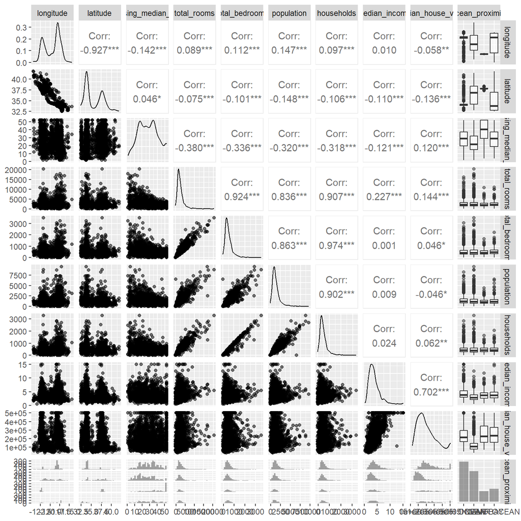

```r
house |>
  drop_na() |>
  sample_frac(size = 0.1) |>
  ggpairs(aes(alpha=0.1))
```

目的変数median_house_valueと最も相関が高いのはmedian_income世帯年収のようなので、そこだけ見た見ましょう。

住宅価格の分布が変ですね。

50万ドルのところに天井効果があるようです。

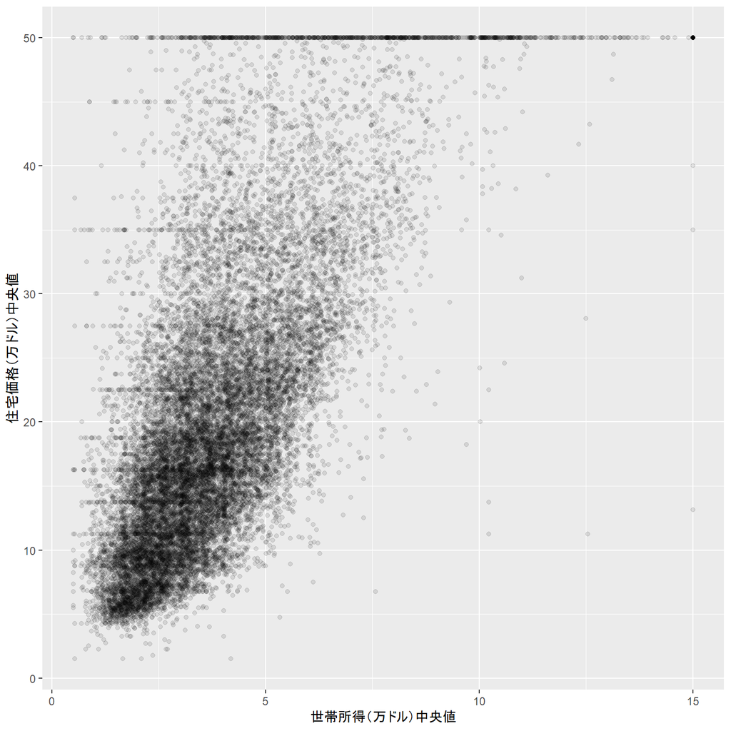

```r
house |>
  ggplot(aes(x = median_income, y = median_house_value / 10000)) +
  geom_point(alpha = 0.1) +
  labs(x = "世帯所得（万ドル）中央値", y = "住宅価格（万ドル）中央値")
```

もう一つ、ocean_proximity: 海への近さがどういう意味なのがつかみづらいので地図を描いてみましょう。

```r
# US Census Bureau（アメリカ統計局）よりsf形式のShape file を取得するパッケージです。
library(tigris)
options(tigris_use_cache = TRUE)
California <- counties("California", cb=TRUE, progress_bar = FALSE)
```

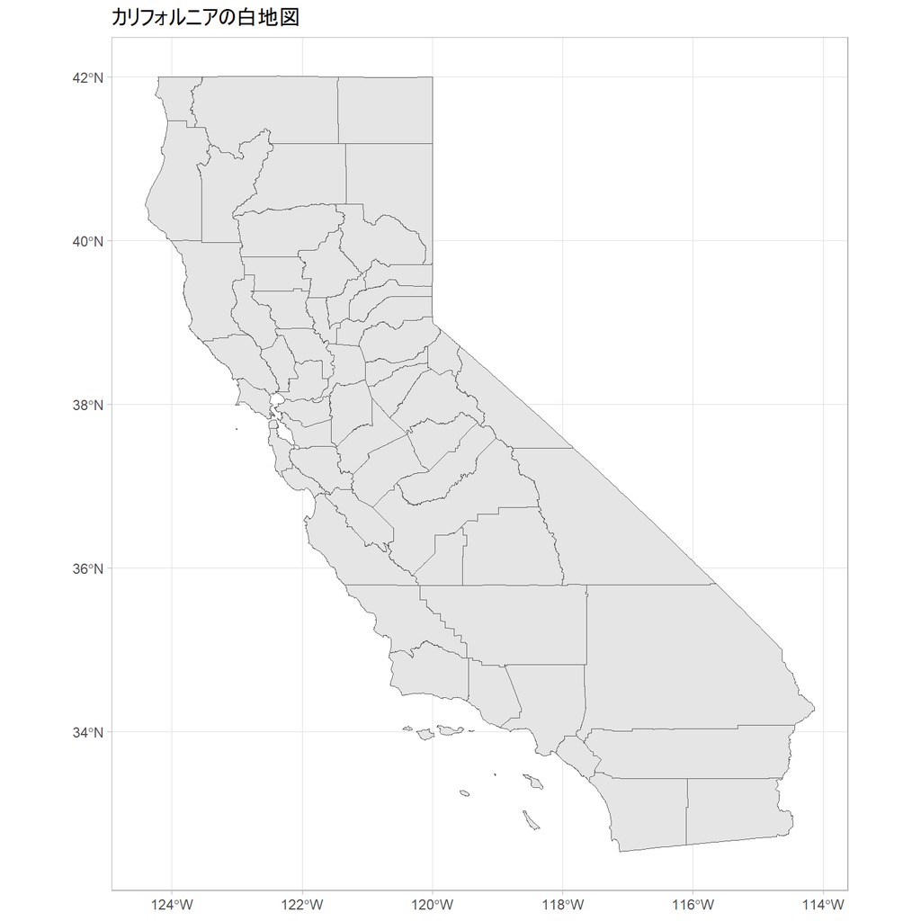

```r
map_cali <- California |>
  ggplot() +
  geom_sf() +
  theme_light()

map_cali +
  labs(title = "カリフォルニアの白地図")
```

ocean_proximity 海への近さを地図上にプロットしてみます。

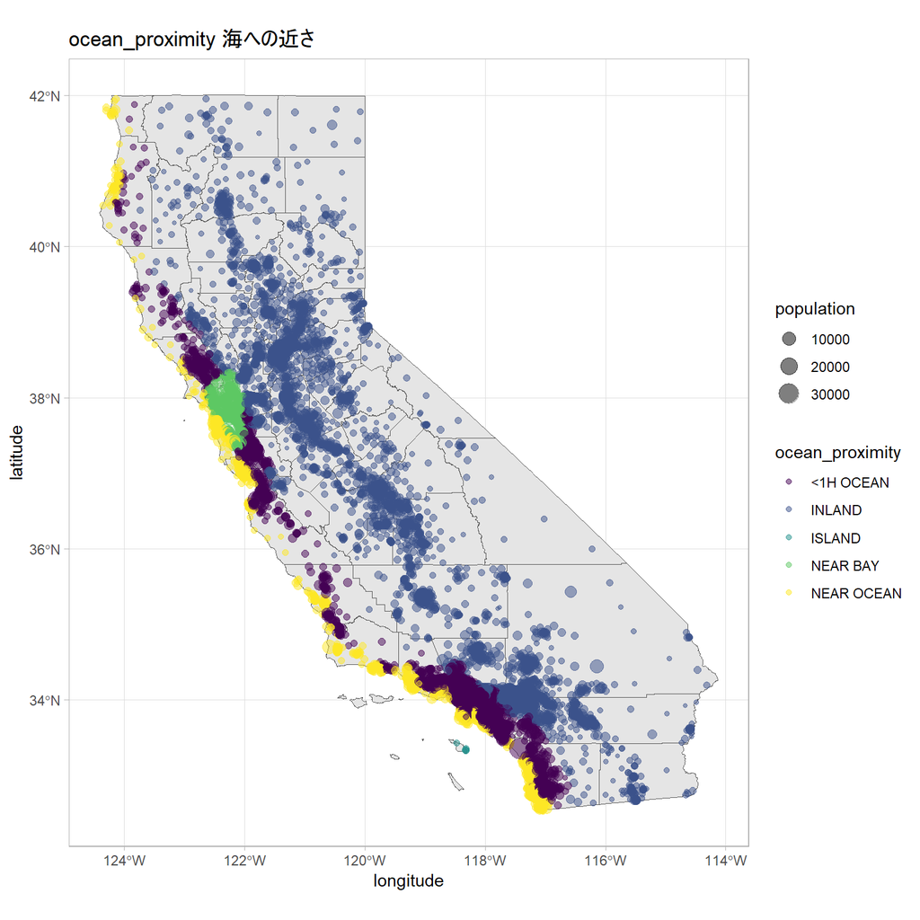

```r
map_cali +
  geom_point(
    data = house,
    aes(x = longitude, y = latitude, color = ocean_proximity, size = population),
    alpha = 0.5
    ) +
  scale_colour_viridis_d() +
  labs(title = "ocean_proximity 海への近さ")
```

目的変数住宅価格

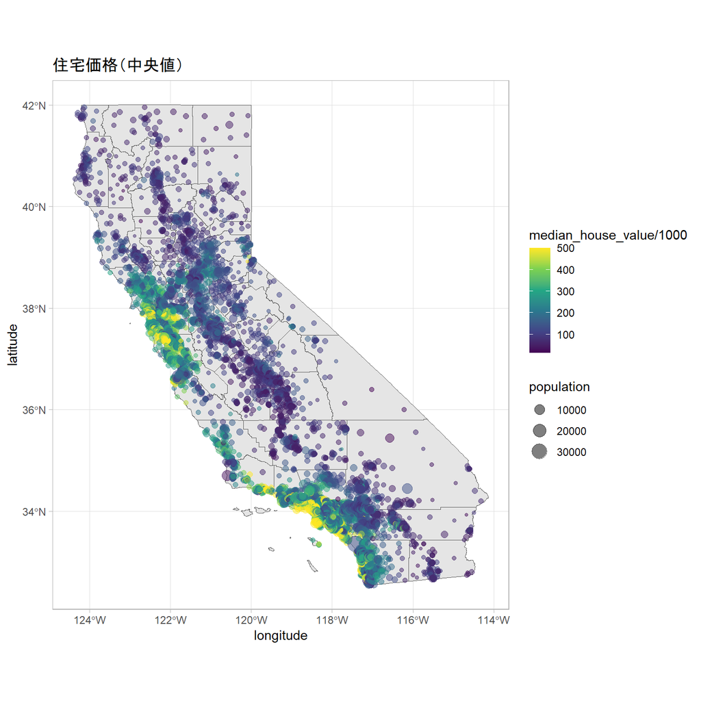

```r
map_cali +
  geom_point(
    data = house,
    aes(x = longitude, y = latitude, color=median_house_value/1000, size = population),
    alpha = 0.5
    ) +
  scale_color_viridis_c() +
  labs(title = "住宅価格（中央値）")
```

このデータをもとにサンプルサイズよりも説明変数の数の方が多いデータセットを作ります。

まず前処理として欠損値のある行とocean_proximityで5件しかないISLANDの行を除きます。

説明変数は以下の加工を行い169個の説明変数を作ります。

- 名義尺度の変数以外で4次までの交互作用項を作る。
- 名義尺度の変数はダミー変数化する。
- 目的変数を万ドル単位に加工。
- 以下の加工した変数を加える。 - total_room/households（世帯当たり部屋数） - total_bedrooms/households（世帯当たり寝室数） - total_bedrooms/total_room（部屋数当たりの寝室数） - population/households（世帯当たり人数）

学習用データとしては100件（0.5%）を抽出。

これでサンプルサイズ100、説明変数169個のデータセットができます。

```r
house_with_dummy <- house |>
  drop_na() |>
  dplyr::filter(ocean_proximity != "ISLAND") |>
  dummy_cols(
    select_columns = "ocean_proximity",
    remove_selected_columns = TRUE,
    remove_most_frequent_dummy = TRUE
    ) |>
  mutate(
    median_house_value = median_house_value / 10000
    )

house_cleaned <- house_with_dummy |>
  model.matrix(median_house_value ~ (.)^4, data = _) |>
  as.data.frame() |>
  dplyr::select(
    !c(`(Intercept)`, contains(":ocean_proximity_"), contains(":`ocean_proximity_"))
    ) |>
  mutate(
    rooms_per_household = total_rooms / households, # 世帯当たり部屋数
    bedrooms_per_household = total_bedrooms / households, # 世帯当たり寝室数
    bedrooms_per_room = total_bedrooms / total_rooms, # 部屋数当たりの寝室数
    population_per_households = population / households, # 世帯当たり人数
    median_house_value = house_with_dummy$median_house_value
    ) |>
  janitor::clean_names()
```

出来上がったもののサンプルサイズと、変数の数を確認しましょう。

```r
house_cleaned |>
  dim()
```

```
## [1] 20428   170
```

ここから学習用データ100件を抽出し、残りを検証用データとします。

```r
house_split_data <- house_cleaned |>
  initial_split(prop = 0.005, strata = "median_house_value") |>
  with_seed(2, code = _)

house_train <- house_split_data |>
  training()

house_test <- house_split_data |>
  testing()
```

学習用データのサンプルサイズと、変数の数を確認しましょう。

無事にサンプルサイズよりも説明変数の数の方が多いデータセットができました。

```r
house_train |>
  dim()
```

```
## [1] 100 170
```

### 各モデルの学習

通常の線形回帰ではそもそも解が求められない。

適応的LASSOも線形回帰の解が求まらないので使えない。

Ridge, LASSO, エラスティックネット、それぞれについて、CVと情報量規準でλを決めたモデルを作る。

#### Ridge

CVでλ選択

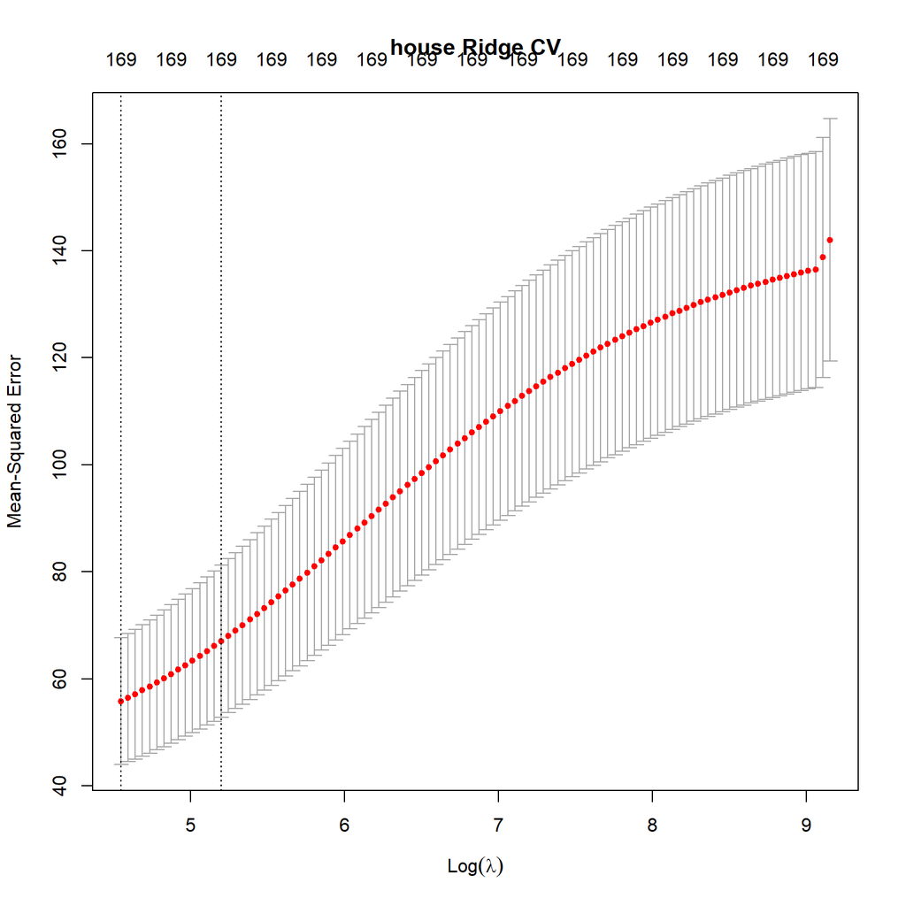

```r
house_ridge_cv <- cv.glmnet(
  median_house_value ~ .,
  data = house_train,
  alpha = 0,
  nfolds = 10
  ) |>
  with_seed(2, code = _)

house_ridge_cv |>
  plot(main = "house Ridge CV")
```

```r
house_ridge_min <- glmnet(
  median_house_value ~ .,
  data = house_train,
  alpha = 0,
  lambda = house_ridge_cv$lambda.min
  )
```

情報量規準でλ選択。

今回は全部同じ値。

```r
house_ic_lambda_ridge <- glmnet(
  median_house_value ~ .,
  data = house_train,
  alpha = 0
  ) |>
  ic_glmnet()

data.frame(
  ic = c("AICc", "BIC", "Cp"),
  best_value = c(
    house_ic_lambda_ridge$lambda_AICc_best,
    house_ic_lambda_ridge$lambda_BIC_best,
    house_ic_lambda_ridge$lambda_Cp_best
  )
)
```

| ic | best_value |
| --- | --- |
| AICc | 94.35258 |
| BIC | 94.35258 |
| Cp | 94.35258 |

```r
house_ridge_ic <- glmnet(
  median_house_value ~ .,
  data = house_train,
  alpha = 0,
  lambda = house_ic_lambda_ridge$lambda_Cp_best
  )
```

#### LASSO

CVでλ選択。

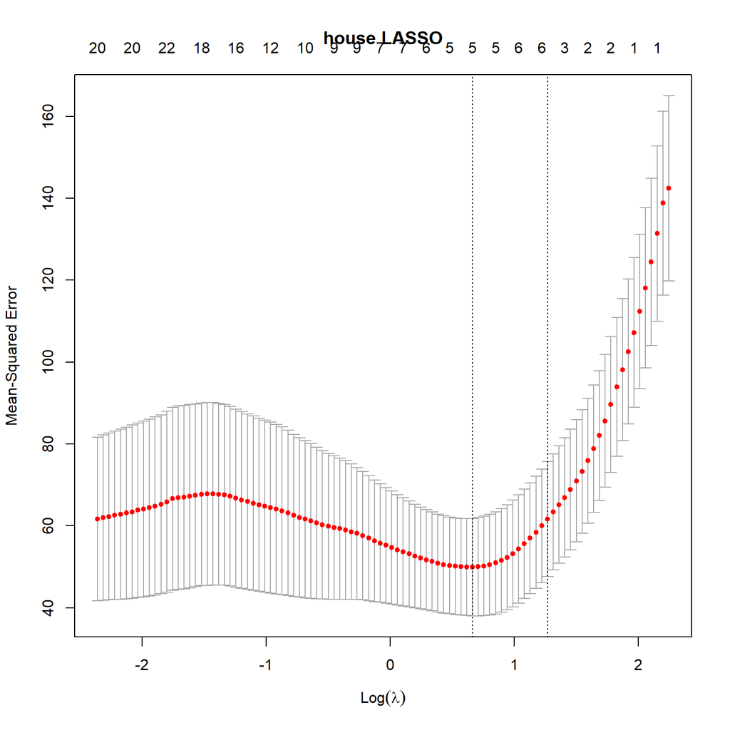

```r
house_lasso_cv <- cv.glmnet(
  median_house_value ~ .,
  data = house_train,
  alpha = 1,
  nfolds = 10
  ) |>
  with_seed(2, code = _)

house_lasso_cv |>
  plot(main = "house LASSO")
```

```r
house_lasso_min <- glmnet(
  median_house_value ~ .,
  data = house_train,
  alpha = 1,
  lambda = house_lasso_cv$lambda.min
  )
```

情報量規準でλ選択。

今回は全部同じ値。

```r
house_ic_lambda_lasso <- glmnet(
  median_house_value ~ .,
  data = house_train,
  alpha = 1
  ) |>
  ic_glmnet()

data.frame(
  ic = c("AICc", "BIC", "Cp"),
  best_value = c(
    house_ic_lambda_lasso$lambda_AICc_best,
    house_ic_lambda_lasso$lambda_BIC_best,
    house_ic_lambda_lasso$lambda_Cp_best
  )
)
```

| ic | best_value |
| --- | --- |
| AICc | 0.09435258 |
| BIC | 0.09435258 |
| Cp | 0.09435258 |

```r
house_lasso_ic <- glmnet(
  median_house_value ~ .,
  data = house_train,
  alpha = 1,
  lambda = house_ic_lambda_lasso$lambda_Cp_best
  )
```

#### エラスティックネット

```r
house_fit_glmnet_L1L2 <- cva.glmnet(
  median_house_value ~ .,
  data = house_train
  ) |>
  with_seed(2, code = _)
```

CVでαとλを探索。

```r
house_en_cv <- house_fit_glmnet_L1L2 |>
  get_cv_best_alpha_lambda()

house_en_cv
```

| best_alpha | best_lambda |
| --- | --- |
| 0.008 | 13.56032 |

情報量規準版でαとλを探索。

```r
house_en_ic <- house_fit_glmnet_L1L2 |>
  get_ic_best_alpha_lambda()

house_en_ic
```

```
## $AICc_best_alpha
## [1] 0.008
##
## $AICc_best_lambda
## [1] 21.59186
##
## $BIC_best_alpha
## [1] 1
##
## $BIC_best_lambda
## [1] 0.09435258
##
## $Cp_best_alpha
## [1] 1
##
## $Cp_best_lambda
## [1] 0.09435258
```

今回はAICcの値を使うことにする。

αとλを当てはめたモデルを作る。

```r
house_EN_min <- glmnet(
  median_house_value ~ .,
  data = house_train,
  alpha = house_en_cv$best_alpha,
  lambda = house_en_cv$best_lambda
  )

house_EN_ic <- glmnet(
  median_house_value ~ .,
  data = house_train,
  alpha = house_en_ic$AICc_best_alpha,
  lambda = house_en_ic$AICc_best_lambda
  )
```

#### 各モデルのあてはまりを評価指標で確認

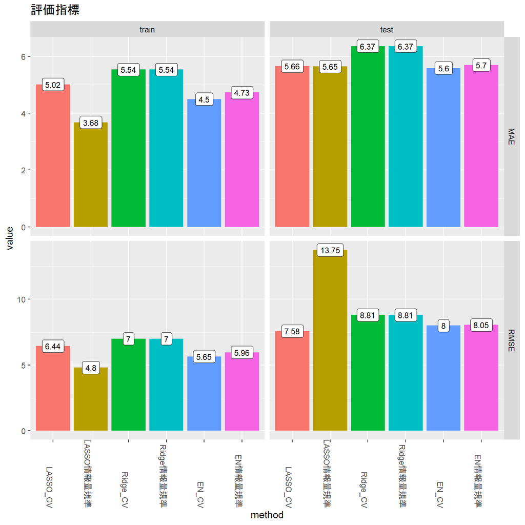

```r
models_house <- list(
  house_lasso_min, house_lasso_ic, house_ridge_min, house_ridge_ic, house_EN_min, house_EN_ic
  )

methods_house <- c(
  "LASSO_CV", "LASSO情報量規準", "Ridge_CV", "Ridge情報量規準", "EN_CV", "EN情報量規準")

MEASURES <- tibble(
  method = methods_house,
  train_MAE = models_house |>
    map_dbl(\(x) MLmetrics::MAE(predict(x, house_train), house_train$median_house_value)),
  test_MAE = models_house |>
    map_dbl(\(x) MLmetrics::MAE(predict(x, house_test), house_test$median_house_value)),
  train_RMSE = models_house |>
    map_dbl(\(x) MLmetrics::RMSE(predict(x, house_train), house_train$median_house_value)),
  test_RMSE = models_house |>
    map_dbl(\(x) MLmetrics::RMSE(predict(x, house_test), house_test$median_house_value))
  ) |>
  pivot_longer(!method) %>%
  mutate(
    type = stringr::str_split(.$name, "_", simplify = TRUE)[, 1] |>
      factor(levels = c("train", "test")),
    measure = stringr::str_split(.$name, "_", simplify = TRUE)[, 2] |>
      factor(levels = c("MAE", "RMSE")),
    method = method |>
      factor(levels = methods_house)
    )

MEASURES |>
  ggplot(aes(x = method, y = value, group = 1, label = round(value, 2))) +
  geom_col(aes(fill = method)) +
  geom_label(size = 3, vjust = 0.5) +
  facet_grid(vars(measure), vars(type), scales = "free") +
  labs(title = "評価指標") +
  theme( axis.text.x = element_text(angle = 270, hjust = 1), legend.position = "none" )
```

予測値と実測値をプロットしてみる。赤い円は95%確率楕円。

外れ値のあてはまりでMAEとRMSEの結果に差が出ている。

天井効果を処理すればLASSO情報量規準が最良で良さそう（ロバストと言える？）。

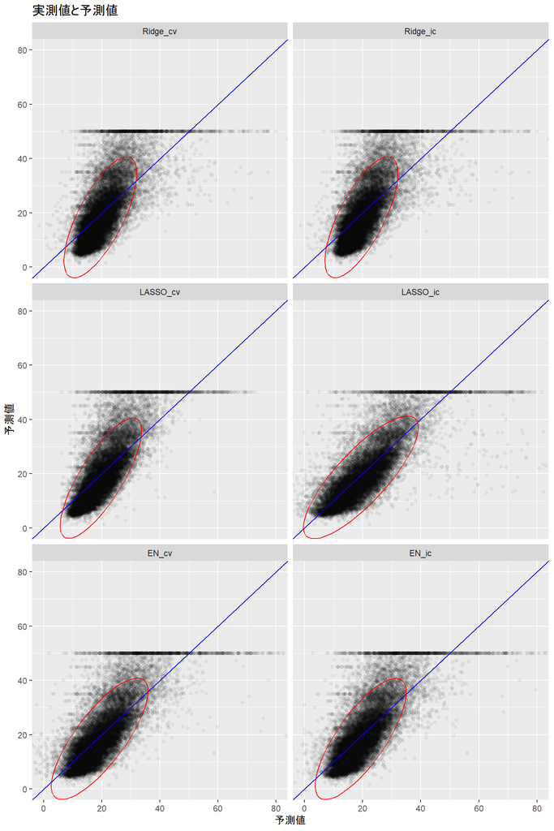

```r
df_true_pred <- models_house |>
  map(\(x) predict(x, house_test)) |>
  as_tibble(.name_repair = "universal") |>
  rename(
    LASSO_cv = ...1,
    LASSO_ic = ...2,
    Ridge_cv = ...3,
    Ridge_ic = ...4,
    EN_cv = ...5,
    EN_ic = ...6
    ) |>
  mutate(true = house_test$median_house_value) |>
  pivot_longer(!true, names_to = "method", values_to = "value") |>
  mutate(method = factor(
    method, levels = c("Ridge_cv", "Ridge_ic", "LASSO_cv", "LASSO_ic", "EN_cv", "EN_ic")
    ))

df_true_pred |>
  ggplot(aes(x = value, y = true)) +
  geom_point(alpha = 0.05) +
  geom_abline(intercept = 0, color = "blue") +
  stat_ellipse(color = "red") +
  coord_cartesian(xlim = c(0, 80), y = c(0, 80)) +
  facet_wrap(vars(method), ncol=2) +
  labs(title = "実測値と予測値", x = "予測値", y = "予測値")
```

#### それぞれの方法の安定性を確認したい

```r
# シミュレーション用関数
sim_f <- function() {
  # データ生成（乱数固定しない）
  house_split_data <- house_cleaned |>
    initial_split(prop = 0.005, strata = "median_house_value")

data <- list(
  house_train = house_split_data |> training(),
  house_test = house_split_data |> testing()
  )

## モデリング
# lasso_cv
house_lasso_cv <- cv.glmnet(
  median_house_value ~ .,
  data = data$house_train,
  alpha = 1,
  nfolds = 10
  ) |>
  with_seed(2, code = _)

house_lasso_min <- glmnet(
  median_house_value ~ .,
  data = data$house_train,
  alpha = 1,
  lambda = house_lasso_cv$lambda.min
  )

# lasso_ic
house_ic_lambda_lasso <- glmnet(
  median_house_value ~ .,
  data = data$house_train,
  alpha = 1
  ) |>
  ic_glmnet()

house_lasso_ic <- glmnet(
  median_house_value ~ .,
  data = data$house_train,
  alpha = 1,
  lambda = house_ic_lambda_lasso$lambda_Cp_best
  )

# ridge_cv
house_ridge_cv <- cv.glmnet(
  median_house_value ~ .,
  data = data$house_train,
  alpha = 0,
  nfolds = 10
  ) |>
  with_seed(2, code = _)

house_ridge_min <- glmnet(
  median_house_value ~ .,
  data = data$house_train,
  alpha = 0,
  lambda = house_ridge_cv$lambda.min
  )

# ridge_ic
house_ic_lambda_ridge <- glmnet(
  median_house_value ~ .,
  data = data$house_train,
  alpha = 0
  ) |>
  ic_glmnet()

house_ridge_ic <- glmnet(
  median_house_value ~ .,
  data = data$house_train,
  alpha = 0,
  lambda = house_ic_lambda_ridge$lambda_Cp_best
  )

# EN
house_fit_glmnet_EN <- cva.glmnet(
  median_house_value ~ .,
  data = house_train
  )

house_en_cv <- house_fit_glmnet_EN |>
  get_cv_best_alpha_lambda()

house_en_ic <- house_fit_glmnet_EN |>
  get_ic_best_alpha_lambda()

house_en_min <- glmnet(
  median_house_value ~ .,
  data = house_train,
  alpha = house_en_cv$best_alpha,
  lambda = house_en_cv$best_lambda
  )

house_en_ic <- glmnet(
  median_house_value ~ .,
  data = house_train,
  alpha = house_en_ic$AICc_best_alpha,
  lambda = house_en_ic$AICc_best_lambda
  )

# 評価
models_house <- list(
  house_ridge_min,
  house_ridge_ic,
  house_lasso_min,
  house_lasso_ic,
  house_en_min,
  house_en_ic
  )

df <- data.frame(
  methods = c("Ridge_cv", "Ridge_ic", "LASSO_cv", "LASSO_ic", "EN_cv", "EN_ic"),
  RMSE = models_house |>
    map_dbl(\(x) MLmetrics::RMSE(predict(x, data$house_test), data$house_test$median_house_value)),
  MAE = models_house |>
    map_dbl(\(x) MLmetrics::MAE(predict(x, data$house_test), data$house_test$median_house_value))
  )

return(df)
}
```

試行実行。時間がかかります。

```r
j <- 300
sim_data <- map(1:j, \(x) sim_f()) |> #, .progress = TRUE
  list_rbind()
```

結果の可視化

LASSOは不安定。おそらく学習用データに含まれる外れ値の量に大きく左右されている。

外れ値の影響で評価が変わっている。

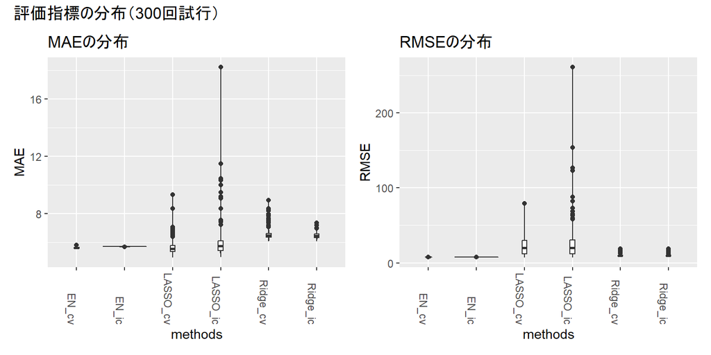

```r
p1 <- sim_data |>
  ggplot(aes(x = methods, y = MAE)) +
  geom_violin(aes(fill = methods)) +
  geom_boxplot(width = 0.1) +
  labs(title = "MAEの分布") +
  theme(axis.text.x = element_text(angle = 270, hjust = 1), legend.position = "none" )

p2 <- sim_data |>
  ggplot(aes(x = methods, y = RMSE)) +
  geom_violin(aes(fill = methods)) +
  geom_boxplot(width = 0.1) +
  labs(title = "RMSEの分布") +
  theme( axis.text.x = element_text(angle = 270, hjust = 1), legend.position = "none" )

p1 + p2 + plot_annotation(title = "評価指標の分布（300回試行）")
```

今回のデータでは、天井効果をどう捉えるかで選ぶべきモデルは変わってくる。

TOPへ戻る